# Risk Factor Analysis

## Outcome Variable

**Outcome Variable:** y_rate_len

## Predictor Variables

**Intervention Variable:** hdlvry

**Adjustment Set:**

- arm
- sex
- W_mage
- meducyrs
- feducyrs
- hhwealth_quart
- W_nrooms
- brthmon
- impfloor
- impsan
- delta_W_mage
- delta_meducyrs
- delta_feducyrs
- delta_hhwealth_quart
- delta_W_nrooms
- delta_brthmon
- delta_impfloor
- delta_impsan

## Stratifying Variables

The analysis was stratified on these variable(s):

- agecat
- studyid
- country

## Data Summary

| agecat | studyid | country | hdlvry | n_cell | n |
| --- | --- | --- | --- | --- | --- |
| 0-3 months | ki1000108-CMC-V-BCS-2002 | INDIA | 0 | 87 | 87 |
| 0-3 months | ki1000108-CMC-V-BCS-2002 | INDIA | 1 | 0 | 87 |
| 0-3 months | ki1000108-IRC | INDIA | 0 | 370 | 377 |
| 0-3 months | ki1000108-IRC | INDIA | 1 | 7 | 377 |
| 0-3 months | ki1000109-EE | PAKISTAN | 0 | 386 | 590 |
| 0-3 months | ki1000109-EE | PAKISTAN | 1 | 204 | 590 |
| 0-3 months | ki1000304b-SAS-CompFeed | INDIA | 0 | 127 | 976 |
| 0-3 months | ki1000304b-SAS-CompFeed | INDIA | 1 | 849 | 976 |
| 0-3 months | ki1017093b-PROVIDE | BANGLADESH | 0 | 474 | 634 |
| 0-3 months | ki1017093b-PROVIDE | BANGLADESH | 1 | 160 | 634 |
| 0-3 months | ki1017093c-NIH-Crypto | BANGLADESH | 0 | 557 | 720 |
| 0-3 months | ki1017093c-NIH-Crypto | BANGLADESH | 1 | 163 | 720 |
| 0-3 months | ki1135781-COHORTS | INDIA | 0 | 2863 | 4580 |
| 0-3 months | ki1135781-COHORTS | INDIA | 1 | 1717 | 4580 |
| 0-3 months | kiGH5241-JiVitA-3 | BANGLADESH | 0 | 66 | 626 |
| 0-3 months | kiGH5241-JiVitA-3 | BANGLADESH | 1 | 560 | 626 |
| 0-3 months | kiGH5241-JiVitA-4 | BANGLADESH | 0 | 738 | 3592 |
| 0-3 months | kiGH5241-JiVitA-4 | BANGLADESH | 1 | 2854 | 3592 |
| 3-6 months | ki1000108-CMC-V-BCS-2002 | INDIA | 0 | 298 | 305 |
| 3-6 months | ki1000108-CMC-V-BCS-2002 | INDIA | 1 | 7 | 305 |
| 3-6 months | ki1000108-IRC | INDIA | 0 | 389 | 397 |
| 3-6 months | ki1000108-IRC | INDIA | 1 | 8 | 397 |
| 3-6 months | ki1000109-EE | PAKISTAN | 0 | 436 | 658 |
| 3-6 months | ki1000109-EE | PAKISTAN | 1 | 222 | 658 |
| 3-6 months | ki1000304b-SAS-CompFeed | INDIA | 0 | 124 | 919 |
| 3-6 months | ki1000304b-SAS-CompFeed | INDIA | 1 | 795 | 919 |
| 3-6 months | ki1017093b-PROVIDE | BANGLADESH | 0 | 428 | 574 |
| 3-6 months | ki1017093b-PROVIDE | BANGLADESH | 1 | 146 | 574 |
| 3-6 months | ki1017093c-NIH-Crypto | BANGLADESH | 0 | 536 | 695 |
| 3-6 months | ki1017093c-NIH-Crypto | BANGLADESH | 1 | 159 | 695 |

[output cut: 52 more lines]

The following strata were considered:

- agecat: 0-3 months, studyid: ki1000108-CMC-V-BCS-2002, country: INDIA
- agecat: 0-3 months, studyid: ki1000108-IRC, country: INDIA
- agecat: 0-3 months, studyid: ki1000109-EE, country: PAKISTAN
- agecat: 0-3 months, studyid: ki1000304b-SAS-CompFeed, country: INDIA
- agecat: 0-3 months, studyid: ki1017093b-PROVIDE, country: BANGLADESH
- agecat: 0-3 months, studyid: ki1017093c-NIH-Crypto, country: BANGLADESH
- agecat: 0-3 months, studyid: ki1135781-COHORTS, country: INDIA
- agecat: 0-3 months, studyid: kiGH5241-JiVitA-3, country: BANGLADESH
- agecat: 0-3 months, studyid: kiGH5241-JiVitA-4, country: BANGLADESH
- agecat: 12-24 months, studyid: ki1000108-CMC-V-BCS-2002, country: INDIA
- agecat: 12-24 months, studyid: ki1000108-IRC, country: INDIA
- agecat: 12-24 months, studyid: ki1017093b-PROVIDE, country: BANGLADESH
- agecat: 12-24 months, studyid: ki1017093c-NIH-Crypto, country: BANGLADESH
- agecat: 12-24 months, studyid: ki1066203-TanzaniaChild2, country: TANZANIA, UNITED REPUBLIC OF
- agecat: 12-24 months, studyid: ki1113344-GMS-Nepal, country: NEPAL
- agecat: 12-24 months, studyid: ki1135781-COHORTS, country: INDIA
- agecat: 12-24 months, studyid: kiGH5241-JiVitA-3, country: BANGLADESH
- agecat: 12-24 months, studyid: kiGH5241-JiVitA-4, country: BANGLADESH
- agecat: 3-6 months, studyid: ki1000108-CMC-V-BCS-2002, country: INDIA
- agecat: 3-6 months, studyid: ki1000108-IRC, country: INDIA
- agecat: 3-6 months, studyid: ki1000109-EE, country: PAKISTAN
- agecat: 3-6 months, studyid: ki1000304b-SAS-CompFeed, country: INDIA
- agecat: 3-6 months, studyid: ki1017093b-PROVIDE, country: BANGLADESH
- agecat: 3-6 months, studyid: ki1017093c-NIH-Crypto, country: BANGLADESH
- agecat: 3-6 months, studyid: ki1066203-TanzaniaChild2, country: TANZANIA, UNITED REPUBLIC OF
- agecat: 3-6 months, studyid: ki1113344-GMS-Nepal, country: NEPAL
- agecat: 3-6 months, studyid: ki1135781-COHORTS, country: INDIA
- agecat: 3-6 months, studyid: kiGH5241-JiVitA-3, country: BANGLADESH
- agecat: 3-6 months, studyid: kiGH5241-JiVitA-4, country: BANGLADESH
- agecat: 6-12 months, studyid: ki1000108-CMC-V-BCS-2002, country: INDIA
- agecat: 6-12 months, studyid: ki1000108-IRC, country: INDIA
- agecat: 6-12 months, studyid: ki1000109-EE, country: PAKISTAN
- agecat: 6-12 months, studyid: ki1000304b-SAS-CompFeed, country: INDIA
- agecat: 6-12 months, studyid: ki1000304b-SAS-FoodSuppl, country: INDIA
- agecat: 6-12 months, studyid: ki1017093b-PROVIDE, country: BANGLADESH
- agecat: 6-12 months, studyid: ki1017093c-NIH-Crypto, country: BANGLADESH
- agecat: 6-12 months, studyid: ki1066203-TanzaniaChild2, country: TANZANIA, UNITED REPUBLIC OF
- agecat: 6-12 months, studyid: ki1113344-GMS-Nepal, country: NEPAL
- agecat: 6-12 months, studyid: ki1135781-COHORTS, country: INDIA
- agecat: 6-12 months, studyid: kiGH5241-JiVitA-3, country: BANGLADESH
- agecat: 6-12 months, studyid: kiGH5241-JiVitA-4, country: BANGLADESH

### Dropped Strata

Some strata were dropped due to rare outcomes:

- agecat: 0-3 months, studyid: ki1000108-CMC-V-BCS-2002, country: INDIA
- agecat: 6-12 months, studyid: ki1000109-EE, country: PAKISTAN
- agecat: 12-24 months, studyid: ki1066203-TanzaniaChild2, country: TANZANIA, UNITED REPUBLIC OF

## Methods Detail

We’re interested in the causal parameters $E[Y_a]$ for all values of $a \in \mathcal{A}$. These parameters represent the mean outcome if, possibly contrary to fact, we intervened to set all units to have $A=a$. Under the randomization and positivity assumptions, these are identified by the statistical parameters $\psi_a=E_W[E_{Y|A,W}(Y|A=a,W)]$. In addition, we’re interested in the mean of $Y$, $E[Y]$ under no intervention (the observed mean). We will estimate these parameters by using SuperLearner to fit the relevant likelihood factors – $E_{Y|A,W}(Y|A=a,W)$ and $p(A=a|W)$, and then updating our likelihood fit using a joint TMLE.

For unadjusted analyses ($W=\{\}$), initial likelihoods were estimated using Lrnr_glm to estimate the simple $E(Y|A)$ and Lrnr_mean to estimate $p(A)$. For adjusted analyses, a small library containing Lrnr_glmnet, Lrnr_xgboost, and Lrnr_mean was used.

# Results Detail

## Results Plots

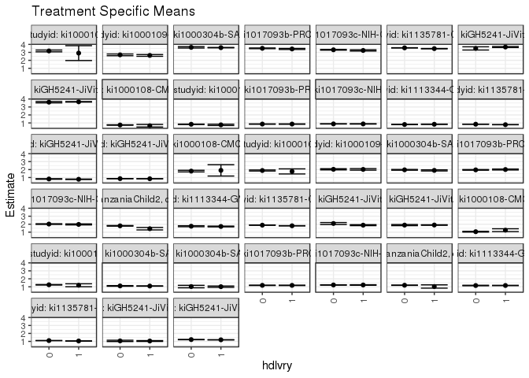

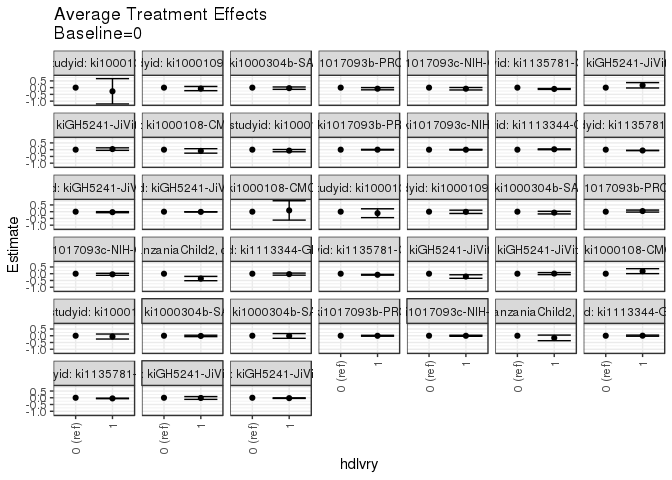

## Results Table

### Parameter: TSM

| agecat | studyid | country | intervention_level | baseline_level | estimate | ci_lower | ci_upper |
| --- | --- | --- | --- | --- | --- | --- | --- |
| 0-3 months | ki1000108-IRC | INDIA | 0 | NA | 3.1779630 | 3.0653103 | 3.2906156 |
| 0-3 months | ki1000108-IRC | INDIA | 1 | NA | 2.9063845 | 1.9745063 | 3.8382627 |
| 0-3 months | ki1000109-EE | PAKISTAN | 0 | NA | 2.6867358 | 2.5778573 | 2.7956144 |
| 0-3 months | ki1000109-EE | PAKISTAN | 1 | NA | 2.6176834 | 2.5060590 | 2.7293077 |
| 0-3 months | ki1000304b-SAS-CompFeed | INDIA | 0 | NA | 3.6275193 | 3.5401725 | 3.7148661 |
| 0-3 months | ki1000304b-SAS-CompFeed | INDIA | 1 | NA | 3.5890680 | 3.5650276 | 3.6131084 |
| 0-3 months | ki1017093b-PROVIDE | BANGLADESH | 0 | NA | 3.5060711 | 3.4601577 | 3.5519845 |
| 0-3 months | ki1017093b-PROVIDE | BANGLADESH | 1 | NA | 3.4267719 | 3.3587588 | 3.4947850 |
| 0-3 months | ki1017093c-NIH-Crypto | BANGLADESH | 0 | NA | 3.3212052 | 3.2777954 | 3.3646151 |
| 0-3 months | ki1017093c-NIH-Crypto | BANGLADESH | 1 | NA | 3.2401965 | 3.1609139 | 3.3194791 |
| 0-3 months | ki1135781-COHORTS | INDIA | 0 | NA | 3.5642269 | 3.5431528 | 3.5853009 |
| 0-3 months | ki1135781-COHORTS | INDIA | 1 | NA | 3.4668060 | 3.4405643 | 3.4930476 |
| 0-3 months | kiGH5241-JiVitA-3 | BANGLADESH | 0 | NA | 3.4969147 | 3.2957640 | 3.6980654 |
| 0-3 months | kiGH5241-JiVitA-3 | BANGLADESH | 1 | NA | 3.6709444 | 3.6083187 | 3.7335701 |
| 0-3 months | kiGH5241-JiVitA-4 | BANGLADESH | 0 | NA | 3.6046610 | 3.5191353 | 3.6901867 |
| 0-3 months | kiGH5241-JiVitA-4 | BANGLADESH | 1 | NA | 3.6470997 | 3.6142565 | 3.6799429 |
| 3-6 months | ki1000108-CMC-V-BCS-2002 | INDIA | 0 | NA | 1.8068881 | 1.7046818 | 1.9090944 |
| 3-6 months | ki1000108-CMC-V-BCS-2002 | INDIA | 1 | NA | 1.9008428 | 1.1896067 | 2.6120788 |
| 3-6 months | ki1000108-IRC | INDIA | 0 | NA | 1.8829475 | 1.8181899 | 1.9477050 |
| 3-6 months | ki1000108-IRC | INDIA | 1 | NA | 1.7701196 | 1.4503290 | 2.0899102 |
| 3-6 months | ki1000109-EE | PAKISTAN | 0 | NA | 2.0304379 | 1.9557436 | 2.1051322 |
| 3-6 months | ki1000109-EE | PAKISTAN | 1 | NA | 2.0209928 | 1.9222684 | 2.1197172 |
| 3-6 months | ki1000304b-SAS-CompFeed | INDIA | 0 | NA | 1.9673305 | 1.9194936 | 2.0151674 |
| 3-6 months | ki1000304b-SAS-CompFeed | INDIA | 1 | NA | 1.8974614 | 1.8278093 | 1.9671135 |
| 3-6 months | ki1017093b-PROVIDE | BANGLADESH | 0 | NA | 1.9616990 | 1.9212253 | 2.0021727 |
| 3-6 months | ki1017093b-PROVIDE | BANGLADESH | 1 | NA | 2.0070876 | 1.9437516 | 2.0704237 |
| 3-6 months | ki1017093c-NIH-Crypto | BANGLADESH | 0 | NA | 2.0163544 | 1.9746554 | 2.0580534 |
| 3-6 months | ki1017093c-NIH-Crypto | BANGLADESH | 1 | NA | 1.9716499 | 1.9085449 | 2.0347549 |
| 3-6 months | ki1066203-TanzaniaChild2 | TANZANIA, UNITED REPUBLIC OF | 0 | NA | 1.7926442 | 1.7556146 | 1.8296739 |
| 3-6 months | ki1066203-TanzaniaChild2 | TANZANIA, UNITED REPUBLIC OF | 1 | NA | 1.4347157 | 1.2806071 | 1.5888243 |
| 3-6 months | ki1113344-GMS-Nepal | NEPAL | 0 | NA | 1.7445548 | 1.6828617 | 1.8062479 |
| 3-6 months | ki1113344-GMS-Nepal | NEPAL | 1 | NA | 1.7126816 | 1.6668060 | 1.7585572 |
| 3-6 months | ki1135781-COHORTS | INDIA | 0 | NA | 1.8798171 | 1.8615533 | 1.8980808 |
| 3-6 months | ki1135781-COHORTS | INDIA | 1 | NA | 1.8010913 | 1.7792139 | 1.8229687 |
| 3-6 months | kiGH5241-JiVitA-3 | BANGLADESH | 0 | NA | 2.0868157 | 1.9633906 | 2.2102408 |
| 3-6 months | kiGH5241-JiVitA-3 | BANGLADESH | 1 | NA | 1.8783924 | 1.8164169 | 1.9403678 |
| 3-6 months | kiGH5241-JiVitA-4 | BANGLADESH | 0 | NA | 1.8864059 | 1.8171492 | 1.9556626 |
| 3-6 months | kiGH5241-JiVitA-4 | BANGLADESH | 1 | NA | 1.8964829 | 1.8646359 | 1.9283299 |
| 6-12 months | ki1000108-CMC-V-BCS-2002 | INDIA | 0 | NA | 1.0590074 | 1.0102042 | 1.1078106 |
| 6-12 months | ki1000108-CMC-V-BCS-2002 | INDIA | 1 | NA | 1.2480272 | 1.0711403 | 1.4249140 |
| 6-12 months | ki1000108-IRC | INDIA | 0 | NA | 1.2497479 | 1.2201637 | 1.2793322 |
| 6-12 months | ki1000108-IRC | INDIA | 1 | NA | 1.1906904 | 1.0068629 | 1.3745179 |
| 6-12 months | ki1000304b-SAS-CompFeed | INDIA | 0 | NA | 1.1076571 | 1.0643660 | 1.1509482 |
| 6-12 months | ki1000304b-SAS-CompFeed | INDIA | 1 | NA | 1.0921020 | 1.0750407 | 1.1091633 |
| 6-12 months | ki1000304b-SAS-FoodSuppl | INDIA | 0 | NA | 1.0266156 | 0.8708352 | 1.1823960 |
| 6-12 months | ki1000304b-SAS-FoodSuppl | INDIA | 1 | NA | 1.0124029 | 0.9275038 | 1.0973021 |
| 6-12 months | ki1017093b-PROVIDE | BANGLADESH | 0 | NA | 1.1810114 | 1.1614219 | 1.2006009 |
| 6-12 months | ki1017093b-PROVIDE | BANGLADESH | 1 | NA | 1.1777762 | 1.1498364 | 1.2057160 |
| 6-12 months | ki1017093c-NIH-Crypto | BANGLADESH | 0 | NA | 1.2283560 | 1.2084329 | 1.2482790 |
| 6-12 months | ki1017093c-NIH-Crypto | BANGLADESH | 1 | NA | 1.2257863 | 1.1934064 | 1.2581663 |
| 6-12 months | ki1066203-TanzaniaChild2 | TANZANIA, UNITED REPUBLIC OF | 0 | NA | 1.1949823 | 1.1729827 | 1.2169820 |
| 6-12 months | ki1066203-TanzaniaChild2 | TANZANIA, UNITED REPUBLIC OF | 1 | NA | 1.0347159 | 0.8290512 | 1.2403807 |
| 6-12 months | ki1113344-GMS-Nepal | NEPAL | 0 | NA | 1.1569507 | 1.1239635 | 1.1899378 |
| 6-12 months | ki1113344-GMS-Nepal | NEPAL | 1 | NA | 1.1611461 | 1.1373264 | 1.1849659 |
| 6-12 months | ki1135781-COHORTS | INDIA | 0 | NA | 1.1027985 | 1.0904859 | 1.1151110 |
| 6-12 months | ki1135781-COHORTS | INDIA | 1 | NA | 1.0551651 | 1.0397487 | 1.0705815 |
| 6-12 months | kiGH5241-JiVitA-3 | BANGLADESH | 0 | NA | 1.0659812 | 0.9858876 | 1.1460747 |
| 6-12 months | kiGH5241-JiVitA-3 | BANGLADESH | 1 | NA | 1.0500123 | 0.9996993 | 1.1003253 |
| 6-12 months | kiGH5241-JiVitA-4 | BANGLADESH | 0 | NA | 1.2264713 | 1.2076234 | 1.2453192 |
| 6-12 months | kiGH5241-JiVitA-4 | BANGLADESH | 1 | NA | 1.1987420 | 1.1862091 | 1.2112749 |
| 12-24 months | ki1000108-CMC-V-BCS-2002 | INDIA | 0 | NA | 0.7400815 | 0.7133492 | 0.7668139 |
| 12-24 months | ki1000108-CMC-V-BCS-2002 | INDIA | 1 | NA | 0.6467578 | 0.4824516 | 0.8110641 |
| 12-24 months | ki1000108-IRC | INDIA | 0 | NA | 0.8309488 | 0.8111401 | 0.8507576 |
| 12-24 months | ki1000108-IRC | INDIA | 1 | NA | 0.7585329 | 0.6770278 | 0.8400381 |
| 12-24 months | ki1017093b-PROVIDE | BANGLADESH | 0 | NA | 0.8572828 | 0.8432321 | 0.8713334 |
| 12-24 months | ki1017093b-PROVIDE | BANGLADESH | 1 | NA | 0.8566994 | 0.8366741 | 0.8767247 |
| 12-24 months | ki1017093c-NIH-Crypto | BANGLADESH | 0 | NA | 0.8776682 | 0.8640222 | 0.8913143 |
| 12-24 months | ki1017093c-NIH-Crypto | BANGLADESH | 1 | NA | 0.8742218 | 0.8520051 | 0.8964384 |
| 12-24 months | ki1113344-GMS-Nepal | NEPAL | 0 | NA | 0.8019458 | 0.7798894 | 0.8240022 |
| 12-24 months | ki1113344-GMS-Nepal | NEPAL | 1 | NA | 0.8311714 | 0.8125440 | 0.8497987 |
| 12-24 months | ki1135781-COHORTS | INDIA | 0 | NA | 0.8383227 | 0.8310549 | 0.8455904 |
| 12-24 months | ki1135781-COHORTS | INDIA | 1 | NA | 0.7769522 | 0.7677411 | 0.7861633 |
| 12-24 months | kiGH5241-JiVitA-3 | BANGLADESH | 0 | NA | 0.8185776 | 0.7825181 | 0.8546371 |
| 12-24 months | kiGH5241-JiVitA-3 | BANGLADESH | 1 | NA | 0.7826315 | 0.7538385 | 0.8114244 |
| 12-24 months | kiGH5241-JiVitA-4 | BANGLADESH | 0 | NA | 0.8609084 | 0.8496976 | 0.8721191 |
| 12-24 months | kiGH5241-JiVitA-4 | BANGLADESH | 1 | NA | 0.8479609 | 0.8413203 | 0.8546014 |

### Parameter: E(Y)

| agecat | studyid | country | intervention_level | baseline_level | estimate | ci_lower | ci_upper |
| --- | --- | --- | --- | --- | --- | --- | --- |
| 0-3 months | ki1000108-IRC | INDIA | NA | NA | 3.1729204 | 3.0609523 | 3.2848884 |
| 0-3 months | ki1000109-EE | PAKISTAN | NA | NA | 2.6584728 | 2.5745279 | 2.7424177 |
| 0-3 months | ki1000304b-SAS-CompFeed | INDIA | NA | NA | 3.5978528 | 3.5675578 | 3.6281478 |
| 0-3 months | ki1017093b-PROVIDE | BANGLADESH | NA | NA | 3.4826706 | 3.4434873 | 3.5218539 |
| 0-3 months | ki1017093c-NIH-Crypto | BANGLADESH | NA | NA | 3.3028656 | 3.2646714 | 3.3410598 |
| 0-3 months | ki1135781-COHORTS | INDIA | NA | NA | 3.5316726 | 3.5145737 | 3.5487714 |
| 0-3 months | kiGH5241-JiVitA-3 | BANGLADESH | NA | NA | 3.6717783 | 3.6046717 | 3.7388850 |
| 0-3 months | kiGH5241-JiVitA-4 | BANGLADESH | NA | NA | 3.6373098 | 3.6059106 | 3.6687089 |
| 3-6 months | ki1000108-CMC-V-BCS-2002 | INDIA | NA | NA | 1.8090444 | 1.7078462 | 1.9102427 |
| 3-6 months | ki1000108-IRC | INDIA | NA | NA | 1.8806738 | 1.8168757 | 1.9444719 |
| 3-6 months | ki1000109-EE | PAKISTAN | NA | NA | 2.0257728 | 1.9650303 | 2.0865152 |
| 3-6 months | ki1000304b-SAS-CompFeed | INDIA | NA | NA | 1.9057893 | 1.8442152 | 1.9673633 |
| 3-6 months | ki1017093b-PROVIDE | BANGLADESH | NA | NA | 1.9654454 | 1.9303798 | 2.0005110 |
| 3-6 months | ki1017093c-NIH-Crypto | BANGLADESH | NA | NA | 2.0057973 | 1.9693775 | 2.0422170 |
| 3-6 months | ki1066203-TanzaniaChild2 | TANZANIA, UNITED REPUBLIC OF | NA | NA | 1.7898602 | 1.7530949 | 1.8266255 |
| 3-6 months | ki1113344-GMS-Nepal | NEPAL | NA | NA | 1.7124798 | 1.6715373 | 1.7534223 |
| 3-6 months | ki1135781-COHORTS | INDIA | NA | NA | 1.8571473 | 1.8427398 | 1.8715548 |
| 3-6 months | kiGH5241-JiVitA-3 | BANGLADESH | NA | NA | 1.8747997 | 1.8153916 | 1.9342078 |
| 3-6 months | kiGH5241-JiVitA-4 | BANGLADESH | NA | NA | 1.8985588 | 1.8677350 | 1.9293826 |
| 6-12 months | ki1000108-CMC-V-BCS-2002 | INDIA | NA | NA | 1.0631293 | 1.0151394 | 1.1111193 |
| 6-12 months | ki1000108-IRC | INDIA | NA | NA | 1.2485668 | 1.2193308 | 1.2778028 |
| 6-12 months | ki1000304b-SAS-CompFeed | INDIA | NA | NA | 1.0945527 | 1.0814129 | 1.1076925 |
| 6-12 months | ki1000304b-SAS-FoodSuppl | INDIA | NA | NA | 1.0131058 | 0.9370457 | 1.0891660 |
| 6-12 months | ki1017093b-PROVIDE | BANGLADESH | NA | NA | 1.1731762 | 1.1558671 | 1.1904853 |
| 6-12 months | ki1017093c-NIH-Crypto | BANGLADESH | NA | NA | 1.2281313 | 1.2106849 | 1.2455776 |
| 6-12 months | ki1066203-TanzaniaChild2 | TANZANIA, UNITED REPUBLIC OF | NA | NA | 1.1937602 | 1.1717617 | 1.2157587 |
| 6-12 months | ki1113344-GMS-Nepal | NEPAL | NA | NA | 1.1671480 | 1.1467111 | 1.1875848 |
| 6-12 months | ki1135781-COHORTS | INDIA | NA | NA | 1.0832218 | 1.0732207 | 1.0932230 |
| 6-12 months | kiGH5241-JiVitA-3 | BANGLADESH | NA | NA | 1.0531497 | 1.0100284 | 1.0962709 |
| 6-12 months | kiGH5241-JiVitA-4 | BANGLADESH | NA | NA | 1.2059987 | 1.1951874 | 1.2168101 |
| 12-24 months | ki1000108-CMC-V-BCS-2002 | INDIA | NA | NA | 0.7380528 | 0.7116168 | 0.7644888 |
| 12-24 months | ki1000108-IRC | INDIA | NA | NA | 0.8294859 | 0.8099817 | 0.8489901 |
| 12-24 months | ki1017093b-PROVIDE | BANGLADESH | NA | NA | 0.8575519 | 0.8455586 | 0.8695452 |
| 12-24 months | ki1017093c-NIH-Crypto | BANGLADESH | NA | NA | 0.8755729 | 0.8637860 | 0.8873598 |
| 12-24 months | ki1113344-GMS-Nepal | NEPAL | NA | NA | 0.8398056 | 0.8238438 | 0.8557674 |
| 12-24 months | ki1135781-COHORTS | INDIA | NA | NA | 0.8173099 | 0.8112554 | 0.8233643 |
| 12-24 months | kiGH5241-JiVitA-3 | BANGLADESH | NA | NA | 0.7811460 | 0.7528156 | 0.8094764 |
| 12-24 months | kiGH5241-JiVitA-4 | BANGLADESH | NA | NA | 0.8509740 | 0.8450306 | 0.8569174 |

### Parameter: ATE

| agecat | studyid | country | intervention_level | baseline_level | estimate | ci_lower | ci_upper |
| --- | --- | --- | --- | --- | --- | --- | --- |
| 0-3 months | ki1000108-IRC | INDIA | 0 | 0 | 0.0000000 | 0.0000000 | 0.0000000 |
| 0-3 months | ki1000108-IRC | INDIA | 1 | 0 | -0.2715785 | -1.2102411 | 0.6670842 |
| 0-3 months | ki1000109-EE | PAKISTAN | 0 | 0 | 0.0000000 | 0.0000000 | 0.0000000 |
| 0-3 months | ki1000109-EE | PAKISTAN | 1 | 0 | -0.0690525 | -0.2243142 | 0.0862093 |
| 0-3 months | ki1000304b-SAS-CompFeed | INDIA | 0 | 0 | 0.0000000 | 0.0000000 | 0.0000000 |
| 0-3 months | ki1000304b-SAS-CompFeed | INDIA | 1 | 0 | -0.0384513 | -0.1250723 | 0.0481697 |
| 0-3 months | ki1017093b-PROVIDE | BANGLADESH | 0 | 0 | 0.0000000 | 0.0000000 | 0.0000000 |
| 0-3 months | ki1017093b-PROVIDE | BANGLADESH | 1 | 0 | -0.0792992 | -0.1613614 | 0.0027629 |
| 0-3 months | ki1017093c-NIH-Crypto | BANGLADESH | 0 | 0 | 0.0000000 | 0.0000000 | 0.0000000 |
| 0-3 months | ki1017093c-NIH-Crypto | BANGLADESH | 1 | 0 | -0.0810088 | -0.1713123 | 0.0092947 |
| 0-3 months | ki1135781-COHORTS | INDIA | 0 | 0 | 0.0000000 | 0.0000000 | 0.0000000 |
| 0-3 months | ki1135781-COHORTS | INDIA | 1 | 0 | -0.0974209 | -0.1305025 | -0.0643393 |
| 0-3 months | kiGH5241-JiVitA-3 | BANGLADESH | 0 | 0 | 0.0000000 | 0.0000000 | 0.0000000 |
| 0-3 months | kiGH5241-JiVitA-3 | BANGLADESH | 1 | 0 | 0.1740297 | -0.0246944 | 0.3727538 |
| 0-3 months | kiGH5241-JiVitA-4 | BANGLADESH | 0 | 0 | 0.0000000 | 0.0000000 | 0.0000000 |
| 0-3 months | kiGH5241-JiVitA-4 | BANGLADESH | 1 | 0 | 0.0424387 | -0.0497087 | 0.1345862 |
| 3-6 months | ki1000108-CMC-V-BCS-2002 | INDIA | 0 | 0 | 0.0000000 | 0.0000000 | 0.0000000 |
| 3-6 months | ki1000108-CMC-V-BCS-2002 | INDIA | 1 | 0 | 0.0939547 | -0.6245875 | 0.8124969 |
| 3-6 months | ki1000108-IRC | INDIA | 0 | 0 | 0.0000000 | 0.0000000 | 0.0000000 |
| 3-6 months | ki1000108-IRC | INDIA | 1 | 0 | -0.1128279 | -0.4391093 | 0.2134535 |
| 3-6 months | ki1000109-EE | PAKISTAN | 0 | 0 | 0.0000000 | 0.0000000 | 0.0000000 |
| 3-6 months | ki1000109-EE | PAKISTAN | 1 | 0 | -0.0094451 | -0.1321481 | 0.1132579 |
| 3-6 months | ki1000304b-SAS-CompFeed | INDIA | 0 | 0 | 0.0000000 | 0.0000000 | 0.0000000 |
| 3-6 months | ki1000304b-SAS-CompFeed | INDIA | 1 | 0 | -0.0698691 | -0.1654764 | 0.0257382 |
| 3-6 months | ki1017093b-PROVIDE | BANGLADESH | 0 | 0 | 0.0000000 | 0.0000000 | 0.0000000 |
| 3-6 months | ki1017093b-PROVIDE | BANGLADESH | 1 | 0 | 0.0453886 | -0.0296051 | 0.1203824 |
| 3-6 months | ki1017093c-NIH-Crypto | BANGLADESH | 0 | 0 | 0.0000000 | 0.0000000 | 0.0000000 |
| 3-6 months | ki1017093c-NIH-Crypto | BANGLADESH | 1 | 0 | -0.0447045 | -0.1189703 | 0.0295612 |
| 3-6 months | ki1066203-TanzaniaChild2 | TANZANIA, UNITED REPUBLIC OF | 0 | 0 | 0.0000000 | 0.0000000 | 0.0000000 |
| 3-6 months | ki1066203-TanzaniaChild2 | TANZANIA, UNITED REPUBLIC OF | 1 | 0 | -0.3579285 | -0.5162805 | -0.1995765 |
| 3-6 months | ki1113344-GMS-Nepal | NEPAL | 0 | 0 | 0.0000000 | 0.0000000 | 0.0000000 |
| 3-6 months | ki1113344-GMS-Nepal | NEPAL | 1 | 0 | -0.0318732 | -0.1085972 | 0.0448509 |
| 3-6 months | ki1135781-COHORTS | INDIA | 0 | 0 | 0.0000000 | 0.0000000 | 0.0000000 |
| 3-6 months | ki1135781-COHORTS | INDIA | 1 | 0 | -0.0787258 | -0.1070979 | -0.0503536 |
| 3-6 months | kiGH5241-JiVitA-3 | BANGLADESH | 0 | 0 | 0.0000000 | 0.0000000 | 0.0000000 |
| 3-6 months | kiGH5241-JiVitA-3 | BANGLADESH | 1 | 0 | -0.2084233 | -0.3399532 | -0.0768934 |
| 3-6 months | kiGH5241-JiVitA-4 | BANGLADESH | 0 | 0 | 0.0000000 | 0.0000000 | 0.0000000 |
| 3-6 months | kiGH5241-JiVitA-4 | BANGLADESH | 1 | 0 | 0.0100770 | -0.0647511 | 0.0849052 |
| 6-12 months | ki1000108-CMC-V-BCS-2002 | INDIA | 0 | 0 | 0.0000000 | 0.0000000 | 0.0000000 |
| 6-12 months | ki1000108-CMC-V-BCS-2002 | INDIA | 1 | 0 | 0.1890198 | 0.0055240 | 0.3725156 |
| 6-12 months | ki1000108-IRC | INDIA | 0 | 0 | 0.0000000 | 0.0000000 | 0.0000000 |
| 6-12 months | ki1000108-IRC | INDIA | 1 | 0 | -0.0590575 | -0.2452504 | 0.1271353 |
| 6-12 months | ki1000304b-SAS-CompFeed | INDIA | 0 | 0 | 0.0000000 | 0.0000000 | 0.0000000 |
| 6-12 months | ki1000304b-SAS-CompFeed | INDIA | 1 | 0 | -0.0155551 | -0.0675328 | 0.0364226 |
| 6-12 months | ki1000304b-SAS-FoodSuppl | INDIA | 0 | 0 | 0.0000000 | 0.0000000 | 0.0000000 |
| 6-12 months | ki1000304b-SAS-FoodSuppl | INDIA | 1 | 0 | -0.0142127 | -0.1901420 | 0.1617167 |
| 6-12 months | ki1017093b-PROVIDE | BANGLADESH | 0 | 0 | 0.0000000 | 0.0000000 | 0.0000000 |
| 6-12 months | ki1017093b-PROVIDE | BANGLADESH | 1 | 0 | -0.0032352 | -0.0363809 | 0.0299105 |
| 6-12 months | ki1017093c-NIH-Crypto | BANGLADESH | 0 | 0 | 0.0000000 | 0.0000000 | 0.0000000 |
| 6-12 months | ki1017093c-NIH-Crypto | BANGLADESH | 1 | 0 | -0.0025696 | -0.0402664 | 0.0351271 |
| 6-12 months | ki1066203-TanzaniaChild2 | TANZANIA, UNITED REPUBLIC OF | 0 | 0 | 0.0000000 | 0.0000000 | 0.0000000 |
| 6-12 months | ki1066203-TanzaniaChild2 | TANZANIA, UNITED REPUBLIC OF | 1 | 0 | -0.1602664 | -0.3671102 | 0.0465774 |
| 6-12 months | ki1113344-GMS-Nepal | NEPAL | 0 | 0 | 0.0000000 | 0.0000000 | 0.0000000 |
| 6-12 months | ki1113344-GMS-Nepal | NEPAL | 1 | 0 | 0.0041954 | -0.0365034 | 0.0448943 |
| 6-12 months | ki1135781-COHORTS | INDIA | 0 | 0 | 0.0000000 | 0.0000000 | 0.0000000 |
| 6-12 months | ki1135781-COHORTS | INDIA | 1 | 0 | -0.0476334 | -0.0672739 | -0.0279928 |
| 6-12 months | kiGH5241-JiVitA-3 | BANGLADESH | 0 | 0 | 0.0000000 | 0.0000000 | 0.0000000 |
| 6-12 months | kiGH5241-JiVitA-3 | BANGLADESH | 1 | 0 | -0.0159689 | -0.1192674 | 0.0873297 |
| 6-12 months | kiGH5241-JiVitA-4 | BANGLADESH | 0 | 0 | 0.0000000 | 0.0000000 | 0.0000000 |
| 6-12 months | kiGH5241-JiVitA-4 | BANGLADESH | 1 | 0 | -0.0277292 | -0.0501784 | -0.0052801 |
| 12-24 months | ki1000108-CMC-V-BCS-2002 | INDIA | 0 | 0 | 0.0000000 | 0.0000000 | 0.0000000 |
| 12-24 months | ki1000108-CMC-V-BCS-2002 | INDIA | 1 | 0 | -0.0933237 | -0.2597904 | 0.0731430 |
| 12-24 months | ki1000108-IRC | INDIA | 0 | 0 | 0.0000000 | 0.0000000 | 0.0000000 |
| 12-24 months | ki1000108-IRC | INDIA | 1 | 0 | -0.0724159 | -0.1562936 | 0.0114618 |
| 12-24 months | ki1017093b-PROVIDE | BANGLADESH | 0 | 0 | 0.0000000 | 0.0000000 | 0.0000000 |
| 12-24 months | ki1017093b-PROVIDE | BANGLADESH | 1 | 0 | -0.0005834 | -0.0248507 | 0.0236840 |
| 12-24 months | ki1017093c-NIH-Crypto | BANGLADESH | 0 | 0 | 0.0000000 | 0.0000000 | 0.0000000 |
| 12-24 months | ki1017093c-NIH-Crypto | BANGLADESH | 1 | 0 | -0.0034465 | -0.0294747 | 0.0225817 |
| 12-24 months | ki1113344-GMS-Nepal | NEPAL | 0 | 0 | 0.0000000 | 0.0000000 | 0.0000000 |
| 12-24 months | ki1113344-GMS-Nepal | NEPAL | 1 | 0 | 0.0292255 | 0.0004627 | 0.0579884 |
| 12-24 months | ki1135781-COHORTS | INDIA | 0 | 0 | 0.0000000 | 0.0000000 | 0.0000000 |
| 12-24 months | ki1135781-COHORTS | INDIA | 1 | 0 | -0.0613705 | -0.0730109 | -0.0497301 |
| 12-24 months | kiGH5241-JiVitA-3 | BANGLADESH | 0 | 0 | 0.0000000 | 0.0000000 | 0.0000000 |
| 12-24 months | kiGH5241-JiVitA-3 | BANGLADESH | 1 | 0 | -0.0359461 | -0.0739936 | 0.0021014 |
| 12-24 months | kiGH5241-JiVitA-4 | BANGLADESH | 0 | 0 | 0.0000000 | 0.0000000 | 0.0000000 |
| 12-24 months | kiGH5241-JiVitA-4 | BANGLADESH | 1 | 0 | -0.0129475 | -0.0254988 | -0.0003962 |